# Explore missing data dependency

Materials from Datacamp summarized by Eleanor Zhang

load packages

```r
library(tidyverse)
library(naniar)
```

## 0.1 Shadow matrix and nabular data

Create a dataset of census data with two variables: income and education

```r
census <- tibble(income = c(48, 40, 52, 31, 89, 103),
                 education = c(NA, NA, "high_school", NA, "university", "university"))
census
```

```
## # A tibble: 6 x 2
##   income education
##    <dbl> <chr>
## 1     48 <NA>
## 2     40 <NA>
## 3     52 high_school
## 4     31 <NA>
## 5     89 university
## 6    103 university
```

Education has missings. If we plot the distribution of income and facet by missings and complete observations:

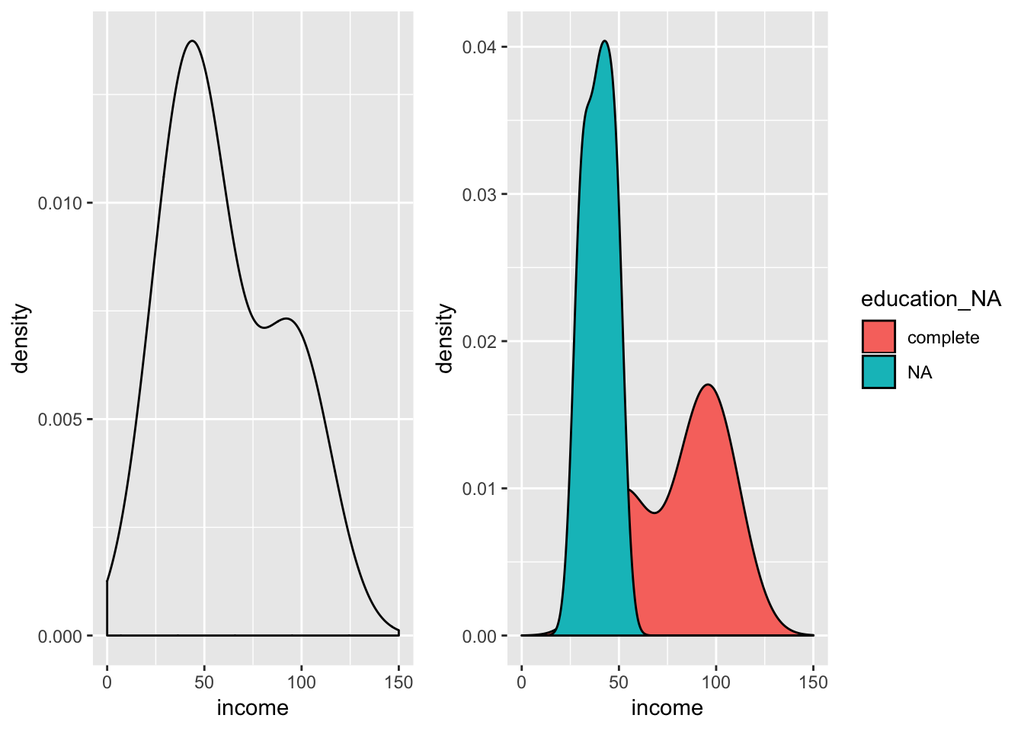

```r
library(patchwork)
census.p1 <- census %>% ggplot(aes(x = income)) + geom_density() + xlim(0,150)
census.p2 <- census %>%
  mutate(education_NA = as.factor(ifelse(is.na(education), "NA", "complete"))) %>%
  ggplot(aes(x = income, fill = education_NA)) + geom_density() + xlim(0,150)

census.p1 + census.p2
```

It can be easily seen that people with missingcrecord in education have lower income as it is shown on the faceting plot. There are tools which assist finding such structures. First of all, we could create a shadow matrix.

Shadown matrix has

- coordinated names: same name as varaible name with a suffix "_NA"; eg. education_NA
- clear values: coded as “NA” or “!NA” (not NA) instead of using 1 or 0

Create nabular data that aligns by column to the original dataset.

## 0.2 Example

Select a few variables from `msleep` dataset

```r
msleep.df <- msleep %>% select(vore, sleep_rem, sleep_total)
msleep.df
```

```
## # A tibble: 83 x 3
##    vore  sleep_rem sleep_total
##    <chr>     <dbl>       <dbl>
##  1 carni      NA          12.1
##  2 omni        1.8        17
##  3 herbi       2.4        14.4
##  4 omni        2.3        14.9
##  5 herbi       0.7         4
##  6 herbi       2.2        14.4
##  7 carni       1.4         8.7
##  8 <NA>       NA           7
##  9 carni       2.9        10.1
## 10 herbi      NA           3
## # … with 73 more rows
```

A shadow matrix explicitly list out if the value is missing or not for each observation in each column:

```r
as_shadow(msleep.df)
```

```
## # A tibble: 83 x 3
##    vore_NA sleep_rem_NA sleep_total_NA
##    <fct>   <fct>        <fct>
##  1 !NA     NA           !NA
##  2 !NA     !NA          !NA
##  3 !NA     !NA          !NA
##  4 !NA     !NA          !NA
##  5 !NA     !NA          !NA
##  6 !NA     !NA          !NA
##  7 !NA     !NA          !NA
##  8 NA      NA           !NA
##  9 !NA     !NA          !NA
## 10 !NA     NA           !NA
## # … with 73 more rows
```

Create nabular data which combines shadow matrix and original dataset. The last three columns are called shadow matrix.

```r
bind_shadow(msleep.df)
```

```
## # A tibble: 83 x 6
##    vore  sleep_rem sleep_total vore_NA sleep_rem_NA sleep_total_NA
##    <chr>     <dbl>       <dbl> <fct>   <fct>        <fct>
##  1 carni      NA          12.1 !NA     NA           !NA
##  2 omni        1.8        17   !NA     !NA          !NA
##  3 herbi       2.4        14.4 !NA     !NA          !NA
##  4 omni        2.3        14.9 !NA     !NA          !NA
##  5 herbi       0.7         4   !NA     !NA          !NA
##  6 herbi       2.2        14.4 !NA     !NA          !NA
##  7 carni       1.4         8.7 !NA     !NA          !NA
##  8 <NA>       NA           7   NA      NA           !NA
##  9 carni       2.9        10.1 !NA     !NA          !NA
## 10 herbi      NA           3   !NA     NA           !NA
## # … with 73 more rows
```

```r
# bind only the variables with missings
bind_shadow(msleep.df, only_miss = TRUE) # "sleep total" has no missings
```

```
## # A tibble: 83 x 5
##    vore  sleep_rem sleep_total vore_NA sleep_rem_NA
##    <chr>     <dbl>       <dbl> <fct>   <fct>
##  1 carni      NA          12.1 !NA     NA
##  2 omni        1.8        17   !NA     !NA
##  3 herbi       2.4        14.4 !NA     !NA
##  4 omni        2.3        14.9 !NA     !NA
##  5 herbi       0.7         4   !NA     !NA
##  6 herbi       2.2        14.4 !NA     !NA
##  7 carni       1.4         8.7 !NA     !NA
##  8 <NA>       NA           7   NA      NA
##  9 carni       2.9        10.1 !NA     !NA
## 10 herbi      NA           3   !NA     NA
## # … with 73 more rows
```

Summarize over missings and non-missings using `group_by()`. For example, we want to find out if the average sleep total is the same between known “vore” and unknown “vores”. In the output, we observe that the mean total sleep time of missings and non-missings in “vore” variable; (there is no missings in sleep time variable). Additional summary statistics can also be computed.

```r
msleep.df %>%
  bind_shadow() %>%
  group_by(vore_NA) %>%
  summarize(sleep.total.mean = mean(sleep_total), # mean
            sleep.total.sd = sd(sleep_total), # sd
            n_obs = n()) # number of missings in vores
```

```
## # A tibble: 2 x 4
##   vore_NA sleep.total.mean sleep.total.sd n_obs
##   <fct>              <dbl>          <dbl> <int>
## 1 !NA                 10.5           4.57    76
## 2 NA                  10.2           3.00     7
```

# 1 Visualize missings with ggplot